# Cars4U Analysis and Prediction

## Create Reference to Libraries and Load Data File

```python
import pandas as pd
import numpy as np

import matplotlib.pyplot as plt
import seaborn as sns

#for scaling/normalizing numerical data
from sklearn.preprocessing import StandardScaler

sns.set()
import scipy as stats

# Removes the limit for the number of displayed columns
pd.set_option("display.max_columns", None)
# Sets the limit for the number of displayed rows
pd.set_option("display.max_rows", 200)

# to split the data into train and test
from sklearn.model_selection import train_test_split

# to build linear regression_model
from sklearn.linear_model import LinearRegression

# to check model performance
from sklearn.metrics import mean_absolute_error, mean_squared_error, r2_score
```

```python
data = pd.read_csv("used_cars_data.csv", index_col=0)
print(f'There are {data.shape[0]} rows and {data.shape[1]} columns.')  # f-string

# Showing 10 random rows for seed(1)
np.random.seed(1)
data.sample(n=10)
```

```
There are 7253 rows and 13 columns.
```

| S.No. | Name | Location | Year | Kilometers_Driven | Fuel_Type | Transmission | Owner_Type | Mileage | Engine | Power | Seats | New_Price | Price |
| --- | --- | --- | --- | --- | --- | --- | --- | --- | --- | --- | --- | --- | --- |
| 2397 | Ford EcoSport 1.5 Petrol Trend | Kolkata | 2016 | 21460 | Petrol | Manual | First | 17.0 kmpl | 1497 CC | 121.36 bhp | 5.0 | 9.47 Lakh | 6.00 |
| 3777 | Maruti Wagon R VXI 1.2 | Kochi | 2015 | 49818 | Petrol | Manual | First | 21.5 kmpl | 1197 CC | 81.80 bhp | 5.0 | 5.44 Lakh | 4.11 |
| 4425 | Ford Endeavour 4x2 XLT | Hyderabad | 2007 | 130000 | Diesel | Manual | First | 13.1 kmpl | 2499 CC | 141 bhp | 7.0 | NaN | 6.00 |
| 3661 | Mercedes-Benz E-Class E250 CDI Avantgrade | Coimbatore | 2016 | 39753 | Diesel | Automatic | First | 13.0 kmpl | 2143 CC | 201.1 bhp | 5.0 | NaN | 35.28 |
| 4514 | Hyundai Xcent 1.2 Kappa AT SX Option | Kochi | 2016 | 45560 | Petrol | Automatic | First | 16.9 kmpl | 1197 CC | 82 bhp | 5.0 | NaN | 6.34 |
| 599 | Toyota Innova Crysta 2.8 ZX AT | Coimbatore | 2019 | 40674 | Diesel | Automatic | First | 11.36 kmpl | 2755 CC | 171.5 bhp | 7.0 | 28.05 Lakh | 24.82 |
| 186 | Mercedes-Benz E-Class E250 CDI Avantgrade | Bangalore | 2014 | 37382 | Diesel | Automatic | First | 13.0 kmpl | 2143 CC | 201.1 bhp | 5.0 | NaN | 32.00 |
| 305 | Audi A6 2011-2015 2.0 TDI Premium Plus | Kochi | 2014 | 61726 | Diesel | Automatic | First | 17.68 kmpl | 1968 CC | 174.33 bhp | 5.0 | NaN | 20.77 |
| 4582 | Hyundai i20 1.2 Magna | Kolkata | 2011 | 36000 | Petrol | Manual | First | 18.5 kmpl | 1197 CC | 80 bhp | 5.0 | NaN | 2.50 |
| 5434 | Honda WR-V Edge Edition i-VTEC S | Kochi | 2019 | 13913 | Petrol | Manual | First | 17.5 kmpl | 1199 CC | 88.7 bhp | 5.0 | 9.36 Lakh | 8.20 |

## Explore Data

```python
data.Fuel_Type.value_counts()
```

```
Diesel      3852
Petrol      3325
CNG           62
LPG           12
Electric       2
Name: Fuel_Type, dtype: int64
```

- As the car name has no statistical value, the Name column will be dropped

```python
#Drop Name Column
data.drop(['Name'],axis=1,inplace=True)
```

```python
np.random.seed(1)
data.sample(n=10)
```

| S.No. | Location | Year | Kilometers_Driven | Fuel_Type | Transmission | Owner_Type | Mileage | Engine | Power | Seats | New_Price | Price |
| --- | --- | --- | --- | --- | --- | --- | --- | --- | --- | --- | --- | --- |
| 2397 | Kolkata | 2016 | 21460 | Petrol | Manual | First | 17.0 kmpl | 1497 CC | 121.36 bhp | 5.0 | 9.47 Lakh | 6.00 |
| 3777 | Kochi | 2015 | 49818 | Petrol | Manual | First | 21.5 kmpl | 1197 CC | 81.80 bhp | 5.0 | 5.44 Lakh | 4.11 |
| 4425 | Hyderabad | 2007 | 130000 | Diesel | Manual | First | 13.1 kmpl | 2499 CC | 141 bhp | 7.0 | NaN | 6.00 |
| 3661 | Coimbatore | 2016 | 39753 | Diesel | Automatic | First | 13.0 kmpl | 2143 CC | 201.1 bhp | 5.0 | NaN | 35.28 |
| 4514 | Kochi | 2016 | 45560 | Petrol | Automatic | First | 16.9 kmpl | 1197 CC | 82 bhp | 5.0 | NaN | 6.34 |
| 599 | Coimbatore | 2019 | 40674 | Diesel | Automatic | First | 11.36 kmpl | 2755 CC | 171.5 bhp | 7.0 | 28.05 Lakh | 24.82 |
| 186 | Bangalore | 2014 | 37382 | Diesel | Automatic | First | 13.0 kmpl | 2143 CC | 201.1 bhp | 5.0 | NaN | 32.00 |
| 305 | Kochi | 2014 | 61726 | Diesel | Automatic | First | 17.68 kmpl | 1968 CC | 174.33 bhp | 5.0 | NaN | 20.77 |
| 4582 | Kolkata | 2011 | 36000 | Petrol | Manual | First | 18.5 kmpl | 1197 CC | 80 bhp | 5.0 | NaN | 2.50 |
| 5434 | Kochi | 2019 | 13913 | Petrol | Manual | First | 17.5 kmpl | 1199 CC | 88.7 bhp | 5.0 | 9.36 Lakh | 8.20 |

```python
print(data.describe(include='all'))
```

```
       Location         Year  Kilometers_Driven Fuel_Type Transmission  \
count      7253  7253.000000       7.253000e+03      7253         7253
unique       11          NaN                NaN         5            2
top      Mumbai          NaN                NaN    Diesel       Manual
freq        949          NaN                NaN      3852         5204
mean        NaN  2013.365366       5.869906e+04       NaN          NaN
std         NaN     3.254421       8.442772e+04       NaN          NaN
min         NaN  1996.000000       1.710000e+02       NaN          NaN
25%         NaN  2011.000000       3.400000e+04       NaN          NaN
50%         NaN  2014.000000       5.341600e+04       NaN          NaN
75%         NaN  2016.000000       7.300000e+04       NaN          NaN
max         NaN  2019.000000       6.500000e+06       NaN          NaN

       Owner_Type    Mileage   Engine   Power        Seats   New_Price  \
count        7253       7251     7207    7207  7200.000000        1006
unique          4        450      150     386          NaN         625
top         First  17.0 kmpl  1197 CC  74 bhp          NaN  63.71 Lakh
freq         5952        207      732     280          NaN           6
mean          NaN        NaN      NaN     NaN     5.279722         NaN
std           NaN        NaN      NaN     NaN     0.811660         NaN
min           NaN        NaN      NaN     NaN     0.000000         NaN
25%           NaN        NaN      NaN     NaN     5.000000         NaN
50%           NaN        NaN      NaN     NaN     5.000000         NaN
75%           NaN        NaN      NaN     NaN     5.000000         NaN
max           NaN        NaN      NaN     NaN    10.000000         NaN

              Price
count   6019.000000
unique          NaN
top             NaN
freq            NaN
mean       9.479468
std       11.187917
min        0.440000
25%        3.500000
50%        5.640000
75%        9.950000
max      160.000000
```

```python
#Checking column data types and non-null counts
data.info()
```

```
<class 'pandas.core.frame.DataFrame'>
Int64Index: 7253 entries, 0 to 7252
Data columns (total 12 columns):
 #   Column             Non-Null Count  Dtype
---  ------             --------------  -----
 0   Location           7253 non-null   object
 1   Year               7253 non-null   int64
 2   Kilometers_Driven  7253 non-null   int64
 3   Fuel_Type          7253 non-null   object
 4   Transmission       7253 non-null   object
 5   Owner_Type         7253 non-null   object
 6   Mileage            7251 non-null   object
 7   Engine             7207 non-null   object
 8   Power              7207 non-null   object
 9   Seats              7200 non-null   float64
 10  New_Price          1006 non-null   object
 11  Price              6019 non-null   float64
dtypes: float64(2), int64(2), object(8)
memory usage: 736.6+ KB
```

- The plan is:
  - Missing Value Imputation/Removal
  - Outlier Detection
  - Normalization and Feature Engineering
  - Prediction

## Missing Value Imputation/Removal and Data Exploration

### Nulls, Data Type Conversions, and Data Cleaning

- Removing nulls from dependent variable.

```python
#Remove Null Price rows
df = data.copy()
df.dropna(subset=["Price"], inplace=True)
df.reset_index()
#Validating Result
#df.isnull().sum().sort_values(ascending=False)
df.count()
```

```
Location             6019
Year                 6019
Kilometers_Driven    6019
Fuel_Type            6019
Transmission         6019
Owner_Type           6019
Mileage              6017
Engine               5983
Power                5983
Seats                5977
New_Price             824
Price                6019
dtype: int64
```

- Year, Kilometers Driven, Seats and Price are numerical values. The rest of the values are objects.
- Fuel_Type, Transmission, Owner_Type, Location, and Seats may be good candidates for converting to dummy variables.
- Mileage, Engine, Power, and New_Price should have their metric descripter trimmed and the column converted to a numerical data type.
- Mileage, Engine, Power, and seats have a small number of nulls while New_Price and Price have a significant number of Nulls.
- Power and Engine have the same number of Null values. Could they be closely correlated and a candidate for dropping one of the columns.
- Since the number of Nulls in the case of seats, power, mileage and engine is low, I would rather remove them than impute them.

```python
#Remove Null seats, power, mileage and engine
df.dropna(subset=["Engine", "Power", "Seats", "Mileage"], inplace=True)
df.reset_index()
#Validating Result
df.isnull().sum().sort_values(ascending=False)
```

```
New_Price            5152
Price                   0
Seats                   0
Power                   0
Engine                  0
Mileage                 0
Owner_Type              0
Transmission            0
Fuel_Type               0
Kilometers_Driven       0
Year                    0
Location                0
dtype: int64
```

```python
df.info()
```

```
<class 'pandas.core.frame.DataFrame'>
Int64Index: 5975 entries, 0 to 6018
Data columns (total 12 columns):
 #   Column             Non-Null Count  Dtype
---  ------             --------------  -----
 0   Location           5975 non-null   object
 1   Year               5975 non-null   int64
 2   Kilometers_Driven  5975 non-null   int64
 3   Fuel_Type          5975 non-null   object
 4   Transmission       5975 non-null   object
 5   Owner_Type         5975 non-null   object
 6   Mileage            5975 non-null   object
 7   Engine             5975 non-null   object
 8   Power              5975 non-null   object
 9   Seats              5975 non-null   float64
 10  New_Price          823 non-null    object
 11  Price              5975 non-null   float64
dtypes: float64(2), int64(2), object(8)
memory usage: 606.8+ KB
```

```python
# Clean Mileage, Engine and Power
#Remove string values from Mileage, Engine, Power
def clean_str(myval):
    if isinstance(myval, str):
        result =(myval.replace('km/kg', '').replace('kmpl','').replace('bhp','').replace('null','').replace('CC','')).strip()
        if result.strip() == '':
            return np.nan
        else:
            return float(result)
    else:
        return np.nan


#Clean mileage column, remove strings and convert to float
df['Mileage'] = df['Mileage'].apply(clean_str)


#Clean Engine column, remove strings and convert to float
df['Engine'] = df['Engine'].apply(clean_str)

#Clean Power column, remove strings and convert to float
df['Power'] = df['Power'].apply(clean_str)
df.reset_index()
```

|  | S.No. | Location | Year | Kilometers_Driven | Fuel_Type | Transmission | Owner_Type | Mileage | Engine | Power | Seats | New_Price | Price |
| --- | --- | --- | --- | --- | --- | --- | --- | --- | --- | --- | --- | --- | --- |
| 0 | 0 | Mumbai | 2010 | 72000 | CNG | Manual | First | 26.60 | 998.0 | 58.16 | 5.0 | NaN | 1.75 |
| 1 | 1 | Pune | 2015 | 41000 | Diesel | Manual | First | 19.67 | 1582.0 | 126.20 | 5.0 | NaN | 12.50 |
| 2 | 2 | Chennai | 2011 | 46000 | Petrol | Manual | First | 18.20 | 1199.0 | 88.70 | 5.0 | 8.61 Lakh | 4.50 |
| 3 | 3 | Chennai | 2012 | 87000 | Diesel | Manual | First | 20.77 | 1248.0 | 88.76 | 7.0 | NaN | 6.00 |
| 4 | 4 | Coimbatore | 2013 | 40670 | Diesel | Automatic | Second | 15.20 | 1968.0 | 140.80 | 5.0 | NaN | 17.74 |
| ... | ... | ... | ... | ... | ... | ... | ... | ... | ... | ... | ... | ... | ... |
| 5970 | 6014 | Delhi | 2014 | 27365 | Diesel | Manual | First | 28.40 | 1248.0 | 74.00 | 5.0 | 7.88 Lakh | 4.75 |
| 5971 | 6015 | Jaipur | 2015 | 100000 | Diesel | Manual | First | 24.40 | 1120.0 | 71.00 | 5.0 | NaN | 4.00 |
| 5972 | 6016 | Jaipur | 2012 | 55000 | Diesel | Manual | Second | 14.00 | 2498.0 | 112.00 | 8.0 | NaN | 2.90 |
| 5973 | 6017 | Kolkata | 2013 | 46000 | Petrol | Manual | First | 18.90 | 998.0 | 67.10 | 5.0 | NaN | 2.65 |
| 5974 | 6018 | Hyderabad | 2011 | 47000 | Diesel | Manual | First | 25.44 | 936.0 | 57.60 | 5.0 | NaN | 2.50 |

5975 rows × 13 columns

```python
df.info()
```

```
<class 'pandas.core.frame.DataFrame'>
Int64Index: 5975 entries, 0 to 6018
Data columns (total 12 columns):
 #   Column             Non-Null Count  Dtype
---  ------             --------------  -----
 0   Location           5975 non-null   object
 1   Year               5975 non-null   int64
 2   Kilometers_Driven  5975 non-null   int64
 3   Fuel_Type          5975 non-null   object
 4   Transmission       5975 non-null   object
 5   Owner_Type         5975 non-null   object
 6   Mileage            5975 non-null   float64
 7   Engine             5975 non-null   float64
 8   Power              5872 non-null   float64
 9   Seats              5975 non-null   float64
 10  New_Price          823 non-null    object
 11  Price              5975 non-null   float64
dtypes: float64(5), int64(2), object(5)
memory usage: 606.8+ KB
```

```python
df.isnull().sum().sort_values(ascending=False)
df.info()
```

```
<class 'pandas.core.frame.DataFrame'>
Int64Index: 5975 entries, 0 to 6018
Data columns (total 12 columns):
 #   Column             Non-Null Count  Dtype
---  ------             --------------  -----
 0   Location           5975 non-null   object
 1   Year               5975 non-null   int64
 2   Kilometers_Driven  5975 non-null   int64
 3   Fuel_Type          5975 non-null   object
 4   Transmission       5975 non-null   object
 5   Owner_Type         5975 non-null   object
 6   Mileage            5975 non-null   float64
 7   Engine             5975 non-null   float64
 8   Power              5872 non-null   float64
 9   Seats              5975 non-null   float64
 10  New_Price          823 non-null    object
 11  Price              5975 non-null   float64
dtypes: float64(5), int64(2), object(5)
memory usage: 606.8+ KB
```

```python
df.dropna(subset=["Power"], inplace=True)
df.isnull().sum().sort_values(ascending=False)
df.reset_index()
```

|  | S.No. | Location | Year | Kilometers_Driven | Fuel_Type | Transmission | Owner_Type | Mileage | Engine | Power | Seats | New_Price | Price |
| --- | --- | --- | --- | --- | --- | --- | --- | --- | --- | --- | --- | --- | --- |
| 0 | 0 | Mumbai | 2010 | 72000 | CNG | Manual | First | 26.60 | 998.0 | 58.16 | 5.0 | NaN | 1.75 |
| 1 | 1 | Pune | 2015 | 41000 | Diesel | Manual | First | 19.67 | 1582.0 | 126.20 | 5.0 | NaN | 12.50 |
| 2 | 2 | Chennai | 2011 | 46000 | Petrol | Manual | First | 18.20 | 1199.0 | 88.70 | 5.0 | 8.61 Lakh | 4.50 |
| 3 | 3 | Chennai | 2012 | 87000 | Diesel | Manual | First | 20.77 | 1248.0 | 88.76 | 7.0 | NaN | 6.00 |
| 4 | 4 | Coimbatore | 2013 | 40670 | Diesel | Automatic | Second | 15.20 | 1968.0 | 140.80 | 5.0 | NaN | 17.74 |
| ... | ... | ... | ... | ... | ... | ... | ... | ... | ... | ... | ... | ... | ... |
| 5867 | 6014 | Delhi | 2014 | 27365 | Diesel | Manual | First | 28.40 | 1248.0 | 74.00 | 5.0 | 7.88 Lakh | 4.75 |
| 5868 | 6015 | Jaipur | 2015 | 100000 | Diesel | Manual | First | 24.40 | 1120.0 | 71.00 | 5.0 | NaN | 4.00 |
| 5869 | 6016 | Jaipur | 2012 | 55000 | Diesel | Manual | Second | 14.00 | 2498.0 | 112.00 | 8.0 | NaN | 2.90 |
| 5870 | 6017 | Kolkata | 2013 | 46000 | Petrol | Manual | First | 18.90 | 998.0 | 67.10 | 5.0 | NaN | 2.65 |
| 5871 | 6018 | Hyderabad | 2011 | 47000 | Diesel | Manual | First | 25.44 | 936.0 | 57.60 | 5.0 | NaN | 2.50 |

5872 rows × 13 columns

- Conforming New_Price data for Lakh.
- The majority of the New_Price column data values is null (86%). I will leave this column as is for now.

```python
#Function to remove Lakh and Cr from New Price and convert Cr to Lakh, by multiplying Cr by 100.
def new_price_to_num(new_price_val):
    """This function takes in a string new price, conforms data to Lakh and returns a float"""
    if isinstance(new_price_val, str):  # checks if `new_pric_val` is a string
        if new_price_val.find('Cr') > -1:
            return float(new_price_val.replace('Cr','')) * 100
        else:
            return float(new_price_val.replace('Lakh',''))
    else:
        return np.nan

df['New_Price'] = df['New_Price'].apply(new_price_to_num)

df.head()
```

| S.No. | Location | Year | Kilometers_Driven | Fuel_Type | Transmission | Owner_Type | Mileage | Engine | Power | Seats | New_Price | Price |
| --- | --- | --- | --- | --- | --- | --- | --- | --- | --- | --- | --- | --- |
| 0 | Mumbai | 2010 | 72000 | CNG | Manual | First | 26.60 | 998.0 | 58.16 | 5.0 | NaN | 1.75 |
| 1 | Pune | 2015 | 41000 | Diesel | Manual | First | 19.67 | 1582.0 | 126.20 | 5.0 | NaN | 12.50 |
| 2 | Chennai | 2011 | 46000 | Petrol | Manual | First | 18.20 | 1199.0 | 88.70 | 5.0 | 8.61 | 4.50 |
| 3 | Chennai | 2012 | 87000 | Diesel | Manual | First | 20.77 | 1248.0 | 88.76 | 7.0 | NaN | 6.00 |
| 4 | Coimbatore | 2013 | 40670 | Diesel | Automatic | Second | 15.20 | 1968.0 | 140.80 | 5.0 | NaN | 17.74 |

```python
df.info()
```

```
<class 'pandas.core.frame.DataFrame'>
Int64Index: 5872 entries, 0 to 6018
Data columns (total 12 columns):
 #   Column             Non-Null Count  Dtype
---  ------             --------------  -----
 0   Location           5872 non-null   object
 1   Year               5872 non-null   int64
 2   Kilometers_Driven  5872 non-null   int64
 3   Fuel_Type          5872 non-null   object
 4   Transmission       5872 non-null   object
 5   Owner_Type         5872 non-null   object
 6   Mileage            5872 non-null   float64
 7   Engine             5872 non-null   float64
 8   Power              5872 non-null   float64
 9   Seats              5872 non-null   float64
 10  New_Price          823 non-null    float64
 11  Price              5872 non-null   float64
dtypes: float64(6), int64(2), object(4)
memory usage: 596.4+ KB
```

```python
df.isnull().sum().sort_values(ascending=False)
```

```
New_Price            5049
Price                   0
Seats                   0
Power                   0
Engine                  0
Mileage                 0
Owner_Type              0
Transmission            0
Fuel_Type               0
Kilometers_Driven       0
Year                    0
Location                0
dtype: int64
```

- Other than New_Price, all nulls have been handled and data types converted.

```python
#Seats
#Seats need to be converted to a non-numeric data type (object) so that it can be converted to a dummy variable.
df['Seats'] = df['Seats'].astype('object')
df.info()
```

```
<class 'pandas.core.frame.DataFrame'>
Int64Index: 5872 entries, 0 to 6018
Data columns (total 12 columns):
 #   Column             Non-Null Count  Dtype
---  ------             --------------  -----
 0   Location           5872 non-null   object
 1   Year               5872 non-null   int64
 2   Kilometers_Driven  5872 non-null   int64
 3   Fuel_Type          5872 non-null   object
 4   Transmission       5872 non-null   object
 5   Owner_Type         5872 non-null   object
 6   Mileage            5872 non-null   float64
 7   Engine             5872 non-null   float64
 8   Power              5872 non-null   float64
 9   Seats              5872 non-null   object
 10  New_Price          823 non-null    float64
 11  Price              5872 non-null   float64
dtypes: float64(5), int64(2), object(5)
memory usage: 596.4+ KB
```

### Duplicates

```python
#Check for duplicates
df.loc[df.duplicated(), :]
```

| S.No. | Location | Year | Kilometers_Driven | Fuel_Type | Transmission | Owner_Type | Mileage | Engine | Power | Seats | New_Price | Price |
| --- | --- | --- | --- | --- | --- | --- | --- | --- | --- | --- | --- | --- |
| 4781 | Hyderabad | 2007 | 52195 | Petrol | Manual | First | 19.7 | 796.0 | 46.3 | 5 | NaN | 1.75 |

```python
df.duplicated().sum()
```

```
1
```

```python
#There is only a single duplicate record.  I will drop the last of these two records to remove the duplicate.
df = df.drop_duplicates(keep="last")
df.reset_index()
df.duplicated().sum()
```

```
0
```

## Outlier Detection

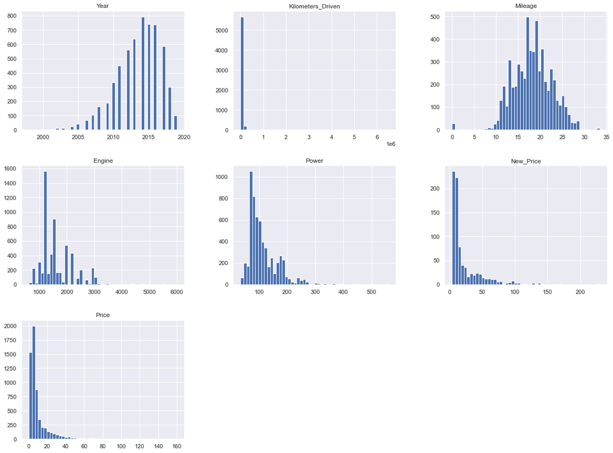

```python
#Checking distribution of data within each numerical feature.
df.hist(bins=50, figsize=(20,15))
plt.show()
```

- Mileage looks relatively normally distributed.
- Year is a bit left skewed but still fairly normally distributed.
- New_Price, Power and Price are all Positively skewed.
- Kilometers driven looks to have large outliers.
- Almost all the cars are 5 seaters.

#### Kilometers_Driven

```python
df.head()
```

| S.No. | Location | Year | Kilometers_Driven | Fuel_Type | Transmission | Owner_Type | Mileage | Engine | Power | Seats | New_Price | Price |
| --- | --- | --- | --- | --- | --- | --- | --- | --- | --- | --- | --- | --- |
| 0 | Mumbai | 2010 | 72000 | CNG | Manual | First | 26.60 | 998.0 | 58.16 | 5 | NaN | 1.75 |
| 1 | Pune | 2015 | 41000 | Diesel | Manual | First | 19.67 | 1582.0 | 126.20 | 5 | NaN | 12.50 |
| 2 | Chennai | 2011 | 46000 | Petrol | Manual | First | 18.20 | 1199.0 | 88.70 | 5 | 8.61 | 4.50 |
| 3 | Chennai | 2012 | 87000 | Diesel | Manual | First | 20.77 | 1248.0 | 88.76 | 7 | NaN | 6.00 |
| 4 | Coimbatore | 2013 | 40670 | Diesel | Automatic | Second | 15.20 | 1968.0 | 140.80 | 5 | NaN | 17.74 |

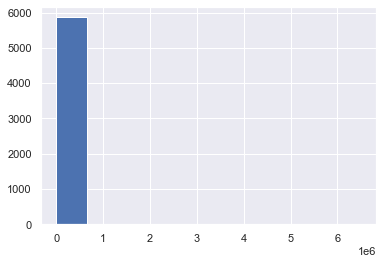

```python
df["Kilometers_Driven"].hist()
```

```python
#Check for outliers by comparing mean to meadian and trim_mean.
print("mean ", df["Kilometers_Driven"].mean())
print("median ", df["Kilometers_Driven"].median())
print("trim mean", stats.stats.trim_mean(df["Kilometers_Driven"],0.1))
print("98th quantile ", np.quantile(df["Kilometers_Driven"],0.98))
print("min ", df["Kilometers_Driven"].min())
print("max ", df["Kilometers_Driven"].max())
```

```
mean  58318.04190086867
median  52618.0
trim mean 53414.32105599319
98th quantile  150000.0
min  171
max  6500000
```

- Max data value looks very off. Its highly unlikely someone drove 6.5 million kilometers in the same car.
- Median is 52618 Kilometers while mean is 58318 Kilometers. It appears that the outliers are skewing the mean significantly.
- I will replace anything greater than the 98th quantile with the 90th quantile.

```python
#copy dataset
df_no_outliers = df.copy()
```

```python
#get rid of anything larger than 98%
def assign_quant98(myval):
    quant98 = np.quantile(df_no_outliers["Kilometers_Driven"], [.98])
    if myval > quant98:
        return np.quantile(df_no_outliers["Kilometers_Driven"], [.90])
    else:
        return myval

df_no_outliers['Kilometers_Driven'] = df_no_outliers['Kilometers_Driven'].apply(assign_quant98)
```

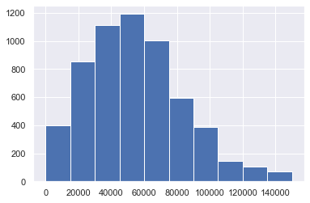

```python
df_no_outliers["Kilometers_Driven"].hist()
```

- Kilometers Driven looks far more normal now.

#### Power

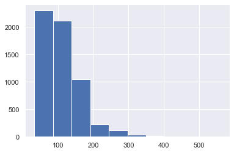

```python
df_no_outliers["Power"].hist()
```

- Power is heavily right skewed.

```python
#Check for outliers by comparing mean to meadian and trim_mean.
print("mean ", df["Power"].mean())
print("median ", df["Power"].median())
print("trim mean", stats.stats.trim_mean(df["Power"],0.1))
print("98th quantile ", np.quantile(df["Power"],0.98))
print("min ", df["Power"].min())
print("max ", df["Power"].max())
```

```
mean  113.28830182251656
median  97.7
trim mean 105.79243346817117
98th quantile  258.0
min  34.2
max  560.0
```

- Mean is significantly greater than either median or trimmed mean. Max is several times greater than the median.

```python
#Modify Power using log to adjust Power to a more normal shape.
df_no_outliers["Power"] = np.log(df_no_outliers["Power"])
```

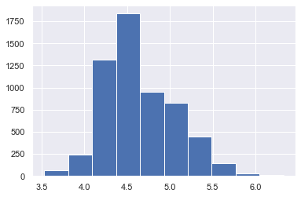

```python
df_no_outliers["Power"].hist()
```

#### Engine

```python
#Check for outliers by comparing mean to meadian and trim_mean.
print("mean ", df["Engine"].mean())
print("median ", df["Engine"].median())
print("trim mean", stats.stats.trim_mean(df["Engine"],0.1))
print("98th quantile ", np.quantile(df["Engine"],0.98))
print("min ", df["Engine"].min())
print("max ", df["Engine"].max())
```

```
mean  1625.88690172032
median  1496.0
trim mean 1550.5565254417713
98th quantile  2993.0
min  624.0
max  5998.0
```

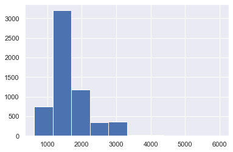

```python
df["Engine"].hist()
```

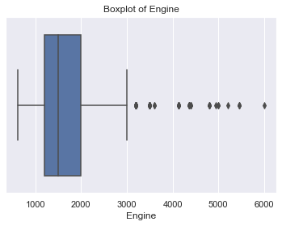

```python
#Taking closer look at Engine.
sns.boxplot(df['Engine'])
plt.title('Boxplot of Engine')
plt.show()
```

- Engine is somewhat right skewed but also has significant number of outliers.

```python
df_no_outliers.reset_index()
df_no_outliers_Engine = df_no_outliers.copy()
```

```python
#get rid of anything larger than 98%
def assign_quant98_Engine(myval):
    quant98 = np.quantile(df_no_outliers["Engine"], [.98])
    if myval > quant98:
        return np.quantile(df_no_outliers["Engine"], [.90])
    else:
        return myval

df_no_outliers_Engine['Engine'] = df_no_outliers['Engine'].apply(assign_quant98_Engine)
```

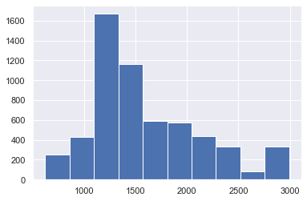

```python
df_no_outliers_Engine['Engine'].hist()
```

- This doesnt normalize Engine enough.

```python
#Modify Engine using log to adjust Engine to a more normal shape.
df_no_outliers_Engine["Engine"] = np.log(df_no_outliers["Engine"])
```

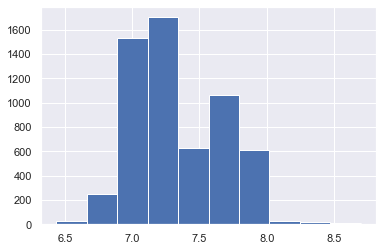

```python
df_no_outliers_Engine["Engine"].hist()
```

```python
#Varifying results of log adjustment of Engine.
print("mean ", df_no_outliers_Engine["Engine"].mean())
print("median ", df_no_outliers_Engine["Engine"].median())
print("trim mean", stats.stats.trim_mean(df_no_outliers_Engine["Engine"],0.1))
print("98th quantile ", np.quantile(df_no_outliers_Engine["Engine"],0.98))
print("min ", df_no_outliers_Engine["Engine"].min())
print("max ", df_no_outliers_Engine["Engine"].max())
```

```
mean  7.334108575313771
median  7.310550158534422
trim mean 7.320191136872312
98th quantile  8.0040315078527
min  6.436150368369428
max  8.699181359308954
```

```python
df_no_outliers = df_no_outliers_Engine.copy()
```

#### Year

```python
#Check for outliers by comparing mean to meadian and trim_mean.
print("mean ", df["Year"].mean())
print("median ", df["Year"].median())
print("trim mean", stats.stats.trim_mean(df["Year"],0.1))
print("98th quantile ", np.quantile(df["Year"],0.98))
print("min ", df["Year"].min())
print("max ", df["Year"].max())
```

```
mean  2013.47879407256
median  2014.0
trim mean 2013.7349371939536
98th quantile  2018.0
min  1998
max  2019
```

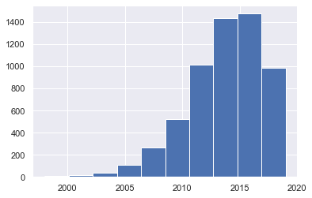

```python
df_no_outliers["Year"].hist()
```

- Year is heavily left skewed. Trying log to see if it normalizes Year.

```python
df_no_outliers_Year = df_no_outliers.copy()
```

```python
#Modify Engine using log to adjust Year to a more normal shape.
df_no_outliers_Year["Year"] = np.log(df_no_outliers["Year"])
```

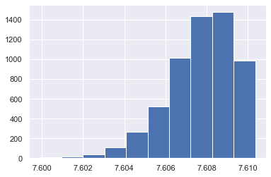

```python
df_no_outliers_Year["Year"].hist()
```

- Graph is still skewed. Trying square root transform.

```python
df_no_outliers_Year = df_no_outliers.copy()
```

```python
#Modify Engine using square root to adjust Year to a more normal shape.
df_no_outliers_Year["Year"] = np.sqrt(df_no_outliers["Year"])
```

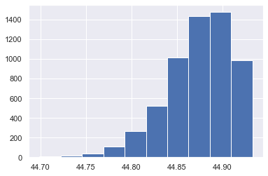

```python
df_no_outliers_Year["Year"].hist()
```

#### Price

```python
#Check for outliers by comparing mean to meadian and trim_mean.
print("mean ", df["Price"].mean())
print("median ", df["Price"].median())
print("trim mean", stats.stats.trim_mean(df["Price"],0.1))
print("98th quantile ", np.quantile(df["Price"],0.98))
print("min ", df["Price"].min())
print("max ", df["Price"].max())
```

```
mean  9.605256344745348
median  5.75
trim mean 7.123925910155418
98th quantile  45.75399999999998
min  0.44
max  160.0
```

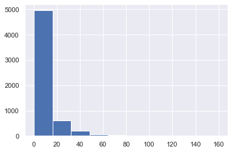

```python
df["Price"].hist()
```

- Price is heavily positively skewed. The mean is almost double the median. Max price is exponentially greater than both the mean and the median. It may be worthwhile to both remove outliers and use a function to reduce the skewness.

```python
df_no_outliers.reset_index()
df_no_outliers_price = df_no_outliers.copy()
```

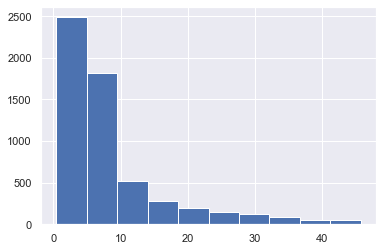

```python
#Trim outliers
Q_Price_98 = np.quantile(df_no_outliers_price["Price"],0.98)
Q_Price_98
df_no_outliers_price = df_no_outliers_price[df_no_outliers_price["Price"] <= Q_Price_98 ]
df_no_outliers_price
df_no_outliers.reset_index()
df_no_outliers_price["Price"].hist()
```

```python
#Attempt to normalize by using log.
df_no_outliers_price["Price"] = np.log(df_no_outliers_price["Price"])
```

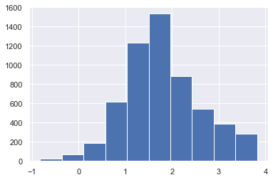

```python
df_no_outliers_price["Price"].hist()
```

- The Price column now looks relatively normal.

```python
df_no_outliers = df_no_outliers_price.copy()
```

```python
df_no_outliers.reset_index()
```

|  | S.No. | Location | Year | Kilometers_Driven | Fuel_Type | Transmission | Owner_Type | Mileage | Engine | Power | Seats | New_Price | Price |
| --- | --- | --- | --- | --- | --- | --- | --- | --- | --- | --- | --- | --- | --- |
| 0 | 0 | Mumbai | 2010 | 72000 | CNG | Manual | First | 26.60 | 6.905753 | 4.063198 | 5 | NaN | 0.559616 |
| 1 | 1 | Pune | 2015 | 41000 | Diesel | Manual | First | 19.67 | 7.366445 | 4.837868 | 5 | NaN | 2.525729 |
| 2 | 2 | Chennai | 2011 | 46000 | Petrol | Manual | First | 18.20 | 7.089243 | 4.485260 | 5 | 8.61 | 1.504077 |
| 3 | 3 | Chennai | 2012 | 87000 | Diesel | Manual | First | 20.77 | 7.129298 | 4.485936 | 7 | NaN | 1.791759 |
| 4 | 4 | Coimbatore | 2013 | 40670 | Diesel | Automatic | Second | 15.20 | 7.584773 | 4.947340 | 5 | NaN | 2.875822 |
| ... | ... | ... | ... | ... | ... | ... | ... | ... | ... | ... | ... | ... | ... |
| 5748 | 6014 | Delhi | 2014 | 27365 | Diesel | Manual | First | 28.40 | 7.129298 | 4.304065 | 5 | 7.88 | 1.558145 |
| 5749 | 6015 | Jaipur | 2015 | 100000 | Diesel | Manual | First | 24.40 | 7.021084 | 4.262680 | 5 | NaN | 1.386294 |
| 5750 | 6016 | Jaipur | 2012 | 55000 | Diesel | Manual | Second | 14.00 | 7.823246 | 4.718499 | 8 | NaN | 1.064711 |
| 5751 | 6017 | Kolkata | 2013 | 46000 | Petrol | Manual | First | 18.90 | 6.905753 | 4.206184 | 5 | NaN | 0.974560 |
| 5752 | 6018 | Hyderabad | 2011 | 47000 | Diesel | Manual | First | 25.44 | 6.841615 | 4.053523 | 5 | NaN | 0.916291 |

5753 rows × 13 columns

### Scale Variables

```python
df_scaled_var = df_no_outliers.copy()
#Instantiate StandardScaler preprocessing class
sc = StandardScaler()
#Create a dataframe with just numeric columns
df_num_col = df_no_outliers.select_dtypes(exclude=['object'])
#Apply fit_transform to numeric columns to scale the numeric variables
df_scaled_var[df_num_col.columns] = sc.fit_transform(df_num_col)

df_scaled_var
```

| S.No. | Location | Year | Kilometers_Driven | Fuel_Type | Transmission | Owner_Type | Mileage | Engine | Power | Seats | New_Price | Price |
| --- | --- | --- | --- | --- | --- | --- | --- | --- | --- | --- | --- | --- |
| 0 | Mumbai | -1.084651 | 72000 | CNG | Manual | First | 1.902915 | -1.272495 | -1.400199 | 5 | NaN | -1.531768 |
| 1 | Pune | 0.497418 | 41000 | Diesel | Manual | First | 0.299106 | 0.141231 | 0.551705 | 5 | NaN | 0.896583 |
| 2 | Chennai | -0.768237 | 46000 | Petrol | Manual | First | -0.041095 | -0.709419 | -0.336747 | 5 | -0.540695 | -0.365261 |
| 3 | Chennai | -0.451823 | 87000 | Diesel | Manual | First | 0.553679 | -0.586504 | -0.335043 | 7 | NaN | -0.009944 |
| 4 | Coimbatore | -0.135409 | 40670 | Diesel | Automatic | Second | -0.735385 | 0.811215 | 0.827539 | 5 | NaN | 1.328985 |
| ... | ... | ... | ... | ... | ... | ... | ... | ... | ... | ... | ... | ... |
| 6014 | Delhi | 0.181004 | 27365 | Diesel | Manual | First | 2.319489 | -0.586504 | -0.793296 | 5 | -0.576867 | -0.298482 |
| 6015 | Jaipur | 0.497418 | 100000 | Diesel | Manual | First | 1.393770 | -0.918580 | -0.897573 | 5 | NaN | -0.510735 |
| 6016 | Jaipur | -0.451823 | 55000 | Diesel | Manual | Second | -1.013101 | 1.543016 | 0.250936 | 8 | NaN | -0.907924 |
| 6017 | Kolkata | -0.135409 | 46000 | Petrol | Manual | First | 0.120906 | -1.272495 | -1.039923 | 5 | NaN | -1.019270 |
| 6018 | Hyderabad | -0.768237 | 47000 | Diesel | Manual | First | 1.634457 | -1.469315 | -1.424578 | 5 | NaN | -1.091238 |

5753 rows × 12 columns

### Correlation

```python
df_scaled_var
```

| S.No. | Location | Year | Kilometers_Driven | Fuel_Type | Transmission | Owner_Type | Mileage | Engine | Power | Seats | New_Price | Price |
| --- | --- | --- | --- | --- | --- | --- | --- | --- | --- | --- | --- | --- |
| 0 | Mumbai | -1.084651 | 72000 | CNG | Manual | First | 1.902915 | -1.272495 | -1.400199 | 5 | NaN | -1.531768 |
| 1 | Pune | 0.497418 | 41000 | Diesel | Manual | First | 0.299106 | 0.141231 | 0.551705 | 5 | NaN | 0.896583 |
| 2 | Chennai | -0.768237 | 46000 | Petrol | Manual | First | -0.041095 | -0.709419 | -0.336747 | 5 | -0.540695 | -0.365261 |
| 3 | Chennai | -0.451823 | 87000 | Diesel | Manual | First | 0.553679 | -0.586504 | -0.335043 | 7 | NaN | -0.009944 |
| 4 | Coimbatore | -0.135409 | 40670 | Diesel | Automatic | Second | -0.735385 | 0.811215 | 0.827539 | 5 | NaN | 1.328985 |
| ... | ... | ... | ... | ... | ... | ... | ... | ... | ... | ... | ... | ... |
| 6014 | Delhi | 0.181004 | 27365 | Diesel | Manual | First | 2.319489 | -0.586504 | -0.793296 | 5 | -0.576867 | -0.298482 |
| 6015 | Jaipur | 0.497418 | 100000 | Diesel | Manual | First | 1.393770 | -0.918580 | -0.897573 | 5 | NaN | -0.510735 |
| 6016 | Jaipur | -0.451823 | 55000 | Diesel | Manual | Second | -1.013101 | 1.543016 | 0.250936 | 8 | NaN | -0.907924 |
| 6017 | Kolkata | -0.135409 | 46000 | Petrol | Manual | First | 0.120906 | -1.272495 | -1.039923 | 5 | NaN | -1.019270 |
| 6018 | Hyderabad | -0.768237 | 47000 | Diesel | Manual | First | 1.634457 | -1.469315 | -1.424578 | 5 | NaN | -1.091238 |

5753 rows × 12 columns

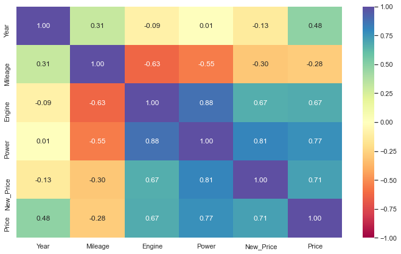

```python
#Checking Correlation
df_scaled_var.reset_index()
plt.figure(figsize=(12, 7))
sns.heatmap(
    df_scaled_var.corr(), annot=True, vmin=-1, vmax=1, fmt=".2f", cmap="Spectral"
)
plt.show()
```

```python
df_scaled_var.corr()
```

|  | Year | Mileage | Engine | Power | New_Price | Price |
| --- | --- | --- | --- | --- | --- | --- |
| Year | 1.000000 | 0.309590 | -0.092421 | 0.008335 | -0.129012 | 0.483987 |
| Mileage | 0.309590 | 1.000000 | -0.625225 | -0.548157 | -0.301807 | -0.280275 |
| Engine | -0.092421 | -0.625225 | 1.000000 | 0.877644 | 0.669295 | 0.673958 |
| Power | 0.008335 | -0.548157 | 0.877644 | 1.000000 | 0.809756 | 0.768013 |
| New_Price | -0.129012 | -0.301807 | 0.669295 | 0.809756 | 1.000000 | 0.711515 |
| Price | 0.483987 | -0.280275 | 0.673958 | 0.768013 | 0.711515 | 1.000000 |

- Engine and Power are highly correlated (87%)
- Price and Power are highly correlated (77%)
- Mileage and Engine are negatively correlated (-63%)
- Power and Price are correlated (77%)
- Price and New_Price are also correlated (71%)
- New_Price and Power are correlated (81%)

#### Create Dummy Variables

```python
#Evaluate Categorical Variables
```

```python
#Check unique values of fuel_type
df_scaled_var.Fuel_Type.unique()
```

```
array(['CNG', 'Diesel', 'Petrol', 'LPG'], dtype=object)
```

```python
df_scaled_var.groupby(["Fuel_Type"]).count()
```

| Fuel_Type | Location | Year | Kilometers_Driven | Transmission | Owner_Type | Mileage | Engine | Power | Seats | New_Price | Price |
| --- | --- | --- | --- | --- | --- | --- | --- | --- | --- | --- | --- |
| CNG | 55 | 55 | 55 | 55 | 55 | 55 | 55 | 55 | 55 | 9 | 55 |
| Diesel | 3054 | 3054 | 3054 | 3054 | 3054 | 3054 | 3054 | 3054 | 3054 | 411 | 3054 |
| LPG | 10 | 10 | 10 | 10 | 10 | 10 | 10 | 10 | 10 | 0 | 10 |
| Petrol | 2634 | 2634 | 2634 | 2634 | 2634 | 2634 | 2634 | 2634 | 2634 | 364 | 2634 |

- Nearly all values are Diesel or Petrol. It may be worthwhile for the business to focus on these two fuel types.

```python
df_scaled_var.groupby(["Location"]).count()
```

| Location | Year | Kilometers_Driven | Fuel_Type | Transmission | Owner_Type | Mileage | Engine | Power | Seats | New_Price | Price |
| --- | --- | --- | --- | --- | --- | --- | --- | --- | --- | --- | --- |
| Ahmedabad | 219 | 219 | 219 | 219 | 219 | 219 | 219 | 219 | 219 | 36 | 219 |
| Bangalore | 332 | 332 | 332 | 332 | 332 | 332 | 332 | 332 | 332 | 31 | 332 |
| Chennai | 468 | 468 | 468 | 468 | 468 | 468 | 468 | 468 | 468 | 47 | 468 |
| Coimbatore | 593 | 593 | 593 | 593 | 593 | 593 | 593 | 593 | 593 | 124 | 593 |
| Delhi | 537 | 537 | 537 | 537 | 537 | 537 | 537 | 537 | 537 | 52 | 537 |
| Hyderabad | 705 | 705 | 705 | 705 | 705 | 705 | 705 | 705 | 705 | 75 | 705 |
| Jaipur | 402 | 402 | 402 | 402 | 402 | 402 | 402 | 402 | 402 | 41 | 402 |
| Kochi | 628 | 628 | 628 | 628 | 628 | 628 | 628 | 628 | 628 | 134 | 628 |
| Kolkata | 517 | 517 | 517 | 517 | 517 | 517 | 517 | 517 | 517 | 53 | 517 |
| Mumbai | 762 | 762 | 762 | 762 | 762 | 762 | 762 | 762 | 762 | 131 | 762 |
| Pune | 590 | 590 | 590 | 590 | 590 | 590 | 590 | 590 | 590 | 60 | 590 |

```python
#If we focus on cities with the most sales what percentage of the business is the top 5 cities?
array = ['Mumbai', 'Kochi', 'Hyderabad','Coimbatore','Pune']
total = df.loc[df['Location'].isin(array)]
num_cities = len(total.index)
num_records = len(df.index)
num_cities/num_records
```

```
0.57230454777721
```

•There are 11 cities with a significant number of car sales in each city. However, 25% of the sales are in Mumbai and Hyderabad alone, and 57% of sales are in Hyderabad, Mumbai, Kochi, Pune, and Caimbatore. The business should focus on these 5 cities to maximize the value of its advertising dollars.

```python
df_scaled_var.groupby(["Transmission"]).count()
```

| Transmission | Location | Year | Kilometers_Driven | Fuel_Type | Owner_Type | Mileage | Engine | Power | Seats | New_Price | Price |
| --- | --- | --- | --- | --- | --- | --- | --- | --- | --- | --- | --- |
| Automatic | 1584 | 1584 | 1584 | 1584 | 1584 | 1584 | 1584 | 1584 | 1584 | 272 | 1584 |
| Manual | 4169 | 4169 | 4169 | 4169 | 4169 | 4169 | 4169 | 4169 | 4169 | 512 | 4169 |

- There are only 2 transmission types with about 2.5 times as many Manual vehicles as Automatic.

```python
df_scaled_var.groupby(["Owner_Type"]).count()
```

| Owner_Type | Location | Year | Kilometers_Driven | Fuel_Type | Transmission | Mileage | Engine | Power | Seats | New_Price | Price |
| --- | --- | --- | --- | --- | --- | --- | --- | --- | --- | --- | --- |
| First | 4731 | 4731 | 4731 | 4731 | 4731 | 4731 | 4731 | 4731 | 4731 | 727 | 4731 |
| Fourth & Above | 7 | 7 | 7 | 7 | 7 | 7 | 7 | 7 | 7 | 0 | 7 |
| Second | 915 | 915 | 915 | 915 | 915 | 915 | 915 | 915 | 915 | 54 | 915 |
| Third | 100 | 100 | 100 | 100 | 100 | 100 | 100 | 100 | 100 | 3 | 100 |

- There are only 4 unique owner types with the vast majority being the First owner.
- There are not too many categorical variable values. Creating all of these columns should be fine.

```python
df_dummies = pd.get_dummies(df_scaled_var, columns = ['Location','Fuel_Type','Transmission','Owner_Type', 'Seats' ], drop_first=True)
```

```python
df_dummies
```

| S.No. | Year | Kilometers_Driven | Mileage | Engine | Power | New_Price | Price | Location_Bangalore | Location_Chennai | Location_Coimbatore | Location_Delhi | Location_Hyderabad | Location_Jaipur | Location_Kochi | Location_Kolkata | Location_Mumbai | Location_Pune | Fuel_Type_Diesel | Fuel_Type_LPG | Fuel_Type_Petrol | Transmission_Manual | Owner_Type_Fourth & Above | Owner_Type_Second | Owner_Type_Third | Seats_4.0 | Seats_5.0 | Seats_6.0 | Seats_7.0 | Seats_8.0 | … |
| --- | --- | --- | --- | --- | --- | --- | --- | --- | --- | --- | --- | --- | --- | --- | --- | --- | --- | --- | --- | --- | --- | --- | --- | --- | --- | --- | --- | --- | --- | --- |
| 0 | -1.084651 | 72000 | 1.902915 | -1.272495 | -1.400199 | NaN | -1.531768 | 0 | 0 | 0 | 0 | 0 | 0 | 0 | 0 | 1 | 0 | 0 | 0 | 0 | 1 | 0 | 0 | 0 | 0 | 1 | 0 | 0 | 0 | … |
| 1 | 0.497418 | 41000 | 0.299106 | 0.141231 | 0.551705 | NaN | 0.896583 | 0 | 0 | 0 | 0 | 0 | 0 | 0 | 0 | 0 | 1 | 1 | 0 | 0 | 1 | 0 | 0 | 0 | 0 | 1 | 0 | 0 | 0 | … |
| 2 | -0.768237 | 46000 | -0.041095 | -0.709419 | -0.336747 | -0.540695 | -0.365261 | 0 | 1 | 0 | 0 | 0 | 0 | 0 | 0 | 0 | 0 | 0 | 0 | 1 | 1 | 0 | 0 | 0 | 0 | 1 | 0 | 0 | 0 | … |
| 3 | -0.451823 | 87000 | 0.553679 | -0.586504 | -0.335043 | NaN | -0.009944 | 0 | 1 | 0 | 0 | 0 | 0 | 0 | 0 | 0 | 0 | 1 | 0 | 0 | 1 | 0 | 0 | 0 | 0 | 0 | 0 | 1 | 0 | … |
| 4 | -0.135409 | 40670 | -0.735385 | 0.811215 | 0.827539 | NaN | 1.328985 | 0 | 0 | 1 | 0 | 0 | 0 | 0 | 0 | 0 | 0 | 1 | 0 | 0 | 0 | 0 | 1 | 0 | 0 | 1 | 0 | 0 | 0 | … |
| ... | ... | ... | ... | ... | ... | ... | ... | ... | ... | ... | ... | ... | ... | ... | ... | ... | ... | ... | ... | ... | ... | ... | ... | ... | ... | ... | ... | ... | ... | … |
| 6014 | 0.181004 | 27365 | 2.319489 | -0.586504 | -0.793296 | -0.576867 | -0.298482 | 0 | 0 | 0 | 1 | 0 | 0 | 0 | 0 | 0 | 0 | 1 | 0 | 0 | 1 | 0 | 0 | 0 | 0 | 1 | 0 | 0 | 0 | … |
| 6015 | 0.497418 | 100000 | 1.393770 | -0.918580 | -0.897573 | NaN | -0.510735 | 0 | 0 | 0 | 0 | 0 | 1 | 0 | 0 | 0 | 0 | 1 | 0 | 0 | 1 | 0 | 0 | 0 | 0 | 1 | 0 | 0 | 0 | … |
| 6016 | -0.451823 | 55000 | -1.013101 | 1.543016 | 0.250936 | NaN | -0.907924 | 0 | 0 | 0 | 0 | 0 | 1 | 0 | 0 | 0 | 0 | 1 | 0 | 0 | 1 | 0 | 1 | 0 | 0 | 0 | 0 | 0 | 1 | … |
| 6017 | -0.135409 | 46000 | 0.120906 | -1.272495 | -1.039923 | NaN | -1.019270 | 0 | 0 | 0 | 0 | 0 | 0 | 0 | 1 | 0 | 0 | 0 | 0 | 1 | 1 | 0 | 0 | 0 | 0 | 1 | 0 | 0 | 0 | … |
| 6018 | -0.768237 | 47000 | 1.634457 | -1.469315 | -1.424578 | NaN | -1.091238 | 0 | 0 | 0 | 0 | 1 | 0 | 0 | 0 | 0 | 0 | 1 | 0 | 0 | 1 | 0 | 0 | 0 | 0 | 1 | 0 | 0 | 0 | … |

5753 rows × 31 columns

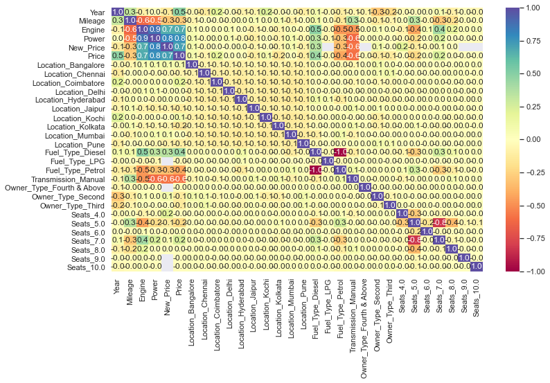

```python
#Reevaluate Correlation
plt.figure(figsize=(12, 7))
sns.heatmap(
    df_dummies.corr(), annot=True, vmin=-1, vmax=1, fmt=".1f", cmap="Spectral"
)
plt.show()
```

```python
df_dummies.corr()
```

|  | Year | Mileage | Engine | Power | New_Price | Price | Location_Bangalore | Location_Chennai | Location_Coimbatore | Location_Delhi | Location_Hyderabad | Location_Jaipur | Location_Kochi | Location_Kolkata | Location_Mumbai | Location_Pune | Fuel_Type_Diesel | Fuel_Type_LPG | Fuel_Type_Petrol | Transmission_Manual | Owner_Type_Fourth & Above | Owner_Type_Second | Owner_Type_Third | Seats_4.0 | Seats_5.0 | Seats_6.0 | Seats_7.0 | Seats_8.0 | Seats_9.0 | … |
| --- | --- | --- | --- | --- | --- | --- | --- | --- | --- | --- | --- | --- | --- | --- | --- | --- | --- | --- | --- | --- | --- | --- | --- | --- | --- | --- | --- | --- | --- | --- |
| Year | 1.000000 | 0.309590 | -0.092421 | 0.008335 | -0.129012 | 0.483987 | -0.046718 | -0.131837 | 0.208421 | -0.006770 | -0.076434 | -0.065808 | 0.229856 | -0.030434 | -0.008615 | -0.105420 | 0.100626 | -0.034698 | -0.102358 | -0.062319 | -0.063101 | -0.294696 | -0.224221 | -0.036200 | -0.014057 | 0.014437 | 0.073284 | -0.086342 | -0.012730 | … |
| Mileage | 0.309590 | 1.000000 | -0.625225 | -0.548157 | -0.301807 | -0.280275 | -0.069458 | -0.002746 | -0.012078 | -0.027913 | 0.033940 | 0.055227 | 0.033482 | 0.065186 | -0.078590 | -0.015511 | 0.112562 | 0.009729 | -0.145508 | 0.348264 | -0.039053 | -0.126441 | -0.075671 | 0.023186 | 0.339197 | -0.041494 | -0.294532 | -0.183107 | -0.025643 | … |
| Engine | -0.092421 | -0.625225 | 1.000000 | 0.877644 | 0.669295 | 0.673958 | 0.068975 | 0.009507 | 0.022643 | 0.054412 | 0.005611 | -0.077455 | -0.028561 | -0.068956 | 0.043600 | -0.030276 | 0.485810 | -0.049813 | -0.462190 | -0.470898 | 0.018493 | 0.058837 | 0.024229 | -0.075418 | -0.424604 | 0.059650 | 0.416061 | 0.166235 | 0.031978 | … |
| Power | 0.008335 | -0.548157 | 0.877644 | 1.000000 | 0.809756 | 0.768013 | 0.081267 | -0.027275 | 0.046646 | 0.058245 | -0.040149 | -0.104606 | 0.010875 | -0.064437 | 0.079458 | -0.048602 | 0.340726 | -0.055477 | -0.313559 | -0.612675 | -0.000939 | 0.038561 | -0.009995 | -0.046750 | -0.204320 | 0.005275 | 0.245743 | 0.005721 | -0.003308 | … |
| New_Price | -0.129012 | -0.301807 | 0.669295 | 0.809756 | 1.000000 | 0.711515 | 0.091135 | -0.043825 | 0.003993 | -0.002826 | 0.037253 | -0.076506 | -0.000547 | -0.068877 | 0.080716 | -0.090245 | 0.347154 | NaN | -0.331622 | -0.572954 | NaN | 0.107262 | -0.012895 | 0.203910 | -0.120173 | -0.034728 | 0.060356 | 0.011019 | NaN | … |
| Price | 0.483987 | -0.280275 | 0.673958 | 0.768013 | 0.711515 | 1.000000 | 0.091622 | -0.070445 | 0.183020 | 0.018640 | 0.021520 | -0.121689 | 0.098324 | -0.152267 | 0.019717 | -0.112719 | 0.436206 | -0.047577 | -0.418852 | -0.591885 | -0.025604 | -0.132192 | -0.129330 | -0.019076 | -0.218786 | 0.024543 | 0.247328 | 0.008171 | -0.008710 | … |
| Location_Bangalore | -0.046718 | -0.069458 | 0.068975 | 0.081267 | 0.091135 | 0.091622 | 1.000000 | -0.073643 | -0.083894 | -0.079405 | -0.092483 | -0.067830 | -0.086629 | -0.077763 | -0.096697 | -0.083657 | 0.036978 | -0.010327 | -0.031427 | -0.062727 | 0.012745 | 0.106385 | 0.035528 | -0.005267 | -0.008335 | 0.003436 | 0.009210 | -0.003350 | 0.026998 | … |
| Location_Chennai | -0.131837 | -0.002746 | 0.009507 | -0.027275 | -0.043825 | -0.070445 | -0.073643 | 1.000000 | -0.100880 | -0.095481 | -0.111208 | -0.081564 | -0.104168 | -0.093507 | -0.116274 | -0.100595 | 0.036390 | -0.012417 | -0.032254 | 0.025419 | 0.026093 | 0.070529 | 0.111246 | -0.009718 | -0.001376 | -0.003224 | -0.006674 | 0.026151 | 0.021055 | … |
| Location_Coimbatore | 0.208421 | -0.012078 | 0.022643 | 0.046646 | 0.003993 | 0.183020 | -0.083894 | -0.100880 | 1.000000 | -0.108773 | -0.126689 | -0.092918 | -0.118668 | -0.106524 | -0.132460 | -0.114598 | 0.008252 | -0.014146 | -0.000578 | -0.061081 | 0.004566 | -0.053639 | -0.040714 | 0.015926 | -0.017674 | 0.016231 | 0.015824 | -0.006502 | -0.007743 | … |
| Location_Delhi | -0.006770 | -0.027913 | 0.054412 | 0.058245 | -0.002826 | 0.018640 | -0.079405 | -0.095481 | -0.108773 | 1.000000 | -0.119909 | -0.087946 | -0.112318 | -0.100824 | -0.125372 | -0.108466 | 0.010694 | -0.013389 | -0.015428 | -0.017584 | -0.011199 | 0.010769 | -0.038104 | -0.009170 | -0.041106 | -0.005964 | 0.043580 | 0.014256 | -0.007329 | … |
| Location_Hyderabad | -0.076434 | 0.033940 | 0.005611 | -0.040149 | 0.037253 | 0.021520 | -0.092483 | -0.111208 | -0.126689 | -0.119909 | 1.000000 | -0.102431 | -0.130818 | -0.117430 | -0.146022 | -0.126331 | 0.119761 | 0.060758 | -0.121060 | 0.016746 | -0.013044 | -0.046568 | -0.049704 | -0.018975 | -0.014168 | 0.010825 | 0.013802 | 0.016584 | -0.008536 | … |
| Location_Jaipur | -0.065808 | 0.055227 | -0.077455 | -0.104606 | -0.076506 | -0.121689 | -0.067830 | -0.081564 | -0.092918 | -0.087946 | -0.102431 | 1.000000 | -0.095946 | -0.086127 | -0.107097 | -0.092655 | 0.018577 | 0.021299 | -0.015129 | 0.089576 | -0.009567 | 0.054183 | 0.031367 | 0.029162 | -0.000208 | 0.009373 | -0.012834 | 0.003205 | -0.006261 | … |
| Location_Kochi | 0.229856 | 0.033482 | -0.028561 | 0.010875 | -0.000547 | 0.098324 | -0.086629 | -0.104168 | -0.118668 | -0.112318 | -0.130818 | -0.095946 | 1.000000 | -0.109996 | -0.136778 | -0.118334 | -0.048449 | -0.014607 | 0.047517 | -0.017583 | -0.012218 | -0.101937 | -0.038028 | 0.013154 | 0.012650 | 0.014438 | -0.007413 | -0.031596 | -0.007996 | … |
| Location_Kolkata | -0.030434 | 0.065186 | -0.068956 | -0.064437 | -0.068877 | -0.152267 | -0.077763 | -0.093507 | -0.106524 | -0.100824 | -0.117430 | -0.086127 | -0.109996 | 1.000000 | -0.122780 | -0.106223 | -0.028561 | -0.013112 | 0.035735 | 0.091639 | -0.010968 | -0.086797 | -0.041793 | -0.023049 | 0.053338 | -0.022366 | -0.045879 | -0.007895 | 0.019445 | … |
| Location_Mumbai | -0.008615 | -0.078590 | 0.043600 | 0.079458 | 0.080716 | 0.019717 | -0.096697 | -0.116274 | -0.132460 | -0.125372 | -0.146022 | -0.107097 | -0.136778 | -0.122780 | 1.000000 | -0.132087 | -0.112523 | -0.003995 | 0.103045 | -0.084026 | 0.001071 | -0.008685 | -0.004886 | 0.003736 | 0.007350 | -0.006090 | -0.008409 | 0.001310 | -0.008925 | … |
| Location_Pune | -0.105420 | -0.015511 | -0.030276 | -0.048602 | -0.090245 | -0.112719 | -0.083657 | -0.100595 | -0.114598 | -0.108466 | -0.126331 | -0.092655 | -0.118334 | -0.106223 | -0.132087 | 1.000000 | -0.045010 | -0.000351 | 0.037800 | 0.031359 | 0.021072 | 0.097387 | 0.077793 | 0.006617 | 0.006782 | -0.007881 | -0.005352 | -0.006252 | -0.007721 | … |
| Fuel_Type_Diesel | 0.100626 | 0.112562 | 0.485810 | 0.340726 | 0.347154 | 0.436206 | 0.036978 | 0.036390 | 0.008252 | 0.010694 | 0.119761 | 0.018577 | -0.048449 | -0.028561 | -0.112523 | -0.045010 | 1.000000 | -0.044388 | -0.977537 | -0.124863 | 0.002838 | -0.022601 | -0.034874 | -0.068505 | -0.272524 | 0.037404 | 0.275990 | 0.114488 | 0.021473 | … |
| Fuel_Type_LPG | -0.034698 | 0.009729 | -0.049813 | -0.055477 | NaN | -0.047577 | -0.010327 | -0.012417 | -0.014146 | -0.013389 | 0.060758 | 0.021299 | -0.014607 | -0.013112 | -0.003995 | -0.000351 | -0.044388 | 1.000000 | -0.038347 | 0.025721 | -0.001456 | 0.004673 | -0.005550 | -0.005079 | 0.017970 | -0.002970 | -0.014802 | -0.006419 | -0.000953 | … |
| Fuel_Type_Petrol | -0.102358 | -0.145508 | -0.462190 | -0.313559 | -0.331622 | -0.418852 | -0.031427 | -0.032254 | -0.000578 | -0.015428 | -0.121060 | -0.015129 | 0.047517 | 0.035735 | 0.103045 | 0.037800 | -0.977537 | -0.038347 | 1.000000 | 0.111091 | -0.002051 | 0.021053 | 0.037948 | 0.053928 | 0.272815 | -0.035852 | -0.272833 | -0.111190 | -0.020991 | … |
| Transmission_Manual | -0.062319 | 0.348264 | -0.470898 | -0.612675 | -0.572954 | -0.591885 | -0.062727 | 0.025419 | -0.061081 | -0.017584 | 0.016746 | 0.089576 | -0.017583 | 0.091639 | -0.084026 | 0.031359 | -0.124863 | 0.025721 | 0.111091 | 1.000000 | 0.010352 | -0.018162 | 0.013499 | -0.077445 | -0.015855 | 0.021895 | 0.006225 | 0.079288 | 0.014080 | … |
| Owner_Type_Fourth & Above | -0.063101 | -0.039053 | 0.018493 | -0.000939 | NaN | -0.025604 | 0.012745 | 0.026093 | 0.004566 | -0.011199 | -0.013044 | -0.009567 | -0.012218 | -0.010968 | 0.001071 | 0.021072 | 0.002838 | -0.001456 | -0.002051 | 0.010352 | 1.000000 | -0.015179 | -0.004642 | -0.004249 | -0.026146 | -0.002484 | 0.019269 | 0.027810 | -0.000797 | … |
| Owner_Type_Second | -0.294696 | -0.126441 | 0.058837 | 0.038561 | 0.107262 | -0.132192 | 0.106385 | 0.070529 | -0.053639 | 0.010769 | -0.046568 | 0.054183 | -0.101937 | -0.086797 | -0.008685 | 0.097387 | -0.022601 | 0.004673 | 0.021053 | -0.018162 | -0.015179 | 1.000000 | -0.057841 | 0.030273 | -0.003738 | -0.010821 | -0.009454 | 0.012166 | -0.009934 | … |
| Owner_Type_Third | -0.224221 | -0.075671 | 0.024229 | -0.009995 | -0.012895 | -0.129330 | 0.035528 | 0.111246 | -0.040714 | -0.038104 | -0.049704 | 0.031367 | -0.038028 | -0.041793 | -0.004886 | 0.077793 | -0.034874 | -0.005550 | 0.037948 | 0.013499 | -0.004642 | -0.057841 | 1.000000 | 0.017075 | -0.019610 | 0.009314 | -0.000746 | 0.023791 | -0.003038 | … |
| Seats_4.0 | -0.036200 | 0.023186 | -0.075418 | -0.046750 | 0.203910 | -0.019076 | -0.005267 | -0.009718 | 0.015926 | -0.009170 | -0.018975 | 0.029162 | 0.013154 | -0.023049 | 0.003736 | 0.006617 | -0.068505 | -0.005079 | 0.053928 | -0.077445 | -0.004249 | 0.030273 | 0.017075 | 1.000000 | -0.282664 | -0.008664 | -0.043180 | -0.018726 | -0.002780 | … |
| Seats_5.0 | -0.014057 | 0.339197 | -0.424604 | -0.204320 | -0.120173 | -0.218786 | -0.008335 | -0.001376 | -0.017674 | -0.041106 | -0.014168 | -0.000208 | 0.012650 | 0.053338 | 0.007350 | 0.006782 | -0.272524 | 0.017970 | 0.272815 | -0.015855 | -0.026146 | -0.003738 | -0.019610 | -0.282664 | 1.000000 | -0.165285 | -0.823719 | -0.357225 | -0.053041 | … |
| Seats_6.0 | 0.014437 | -0.041494 | 0.059650 | 0.005275 | -0.034728 | 0.024543 | 0.003436 | -0.003224 | 0.016231 | -0.005964 | 0.010825 | 0.009373 | 0.014438 | -0.022366 | -0.006090 | -0.007881 | 0.037404 | -0.002970 | -0.035852 | 0.021895 | -0.002484 | -0.010821 | 0.009314 | -0.008664 | -0.165285 | 1.000000 | -0.025249 | -0.010950 | -0.001626 | … |
| Seats_7.0 | 0.073284 | -0.294532 | 0.416061 | 0.245743 | 0.060356 | 0.247328 | 0.009210 | -0.006674 | 0.015824 | 0.043580 | 0.013802 | -0.012834 | -0.007413 | -0.045879 | -0.008409 | -0.005352 | 0.275990 | -0.014802 | -0.272833 | 0.006225 | 0.019269 | -0.009454 | -0.000746 | -0.043180 | -0.823719 | -0.025249 | 1.000000 | -0.054570 | -0.008103 | … |
| Seats_8.0 | -0.086342 | -0.183107 | 0.166235 | 0.005721 | 0.011019 | 0.008171 | -0.003350 | 0.026151 | -0.006502 | 0.014256 | 0.016584 | 0.003205 | -0.031596 | -0.007895 | 0.001310 | -0.006252 | 0.114488 | -0.006419 | -0.111190 | 0.079288 | 0.027810 | 0.012166 | 0.023791 | -0.018726 | -0.357225 | -0.010950 | -0.054570 | 1.000000 | -0.003514 | … |
| Seats_9.0 | -0.012730 | -0.025643 | 0.031978 | -0.003308 | NaN | -0.008710 | 0.026998 | 0.021055 | -0.007743 | -0.007329 | -0.008536 | -0.006261 | -0.007996 | 0.019445 | -0.008925 | -0.007721 | 0.021473 | -0.000953 | -0.020991 | 0.014080 | -0.000797 | -0.009934 | -0.003038 | -0.002780 | -0.053041 | -0.001626 | -0.008103 | -0.003514 | 1.000000 | … |
| Seats_10.0 | -0.041130 | -0.028142 | 0.035134 | -0.017257 | NaN | -0.010497 | 0.021751 | -0.007849 | -0.008942 | -0.008464 | 0.010253 | -0.007230 | -0.009234 | -0.008289 | 0.009147 | 0.012820 | 0.024797 | -0.001101 | -0.024240 | 0.016259 | -0.000921 | 0.006560 | 0.046950 | -0.003211 | -0.061252 | -0.001878 | -0.009357 | -0.004058 | -0.000603 | … |

I will attempt to run the model with and without the New_Price column. I will then remove the highly correlated columns from the better performing model from the previous step to see if that improves performance.

## Prediction

### Model 1 - Model without New Price Column

```python
#Before Building the Model, I will handle the New_Price Nulls by dropping the New_Price column before building the model
#First I will remove the New_Price Column and build a model

#First copy dataframe
df_no_new_price = df_dummies.copy()

#Next drop New_Price
df_no_new_price.drop(['New_Price'], axis=1, inplace=True)

df_no_new_price.reset_index()
```

|  | S.No. | Year | Kilometers_Driven | Mileage | Engine | Power | Price | Location_Bangalore | Location_Chennai | Location_Coimbatore | Location_Delhi | Location_Hyderabad | Location_Jaipur | Location_Kochi | Location_Kolkata | Location_Mumbai | Location_Pune | Fuel_Type_Diesel | Fuel_Type_LPG | Fuel_Type_Petrol | Transmission_Manual | Owner_Type_Fourth & Above | Owner_Type_Second | Owner_Type_Third | Seats_4.0 | Seats_5.0 | Seats_6.0 | Seats_7.0 | Seats_8.0 | … |
| --- | --- | --- | --- | --- | --- | --- | --- | --- | --- | --- | --- | --- | --- | --- | --- | --- | --- | --- | --- | --- | --- | --- | --- | --- | --- | --- | --- | --- | --- | --- |
| 0 | 0 | -1.084651 | 72000 | 1.902915 | -1.272495 | -1.400199 | -1.531768 | 0 | 0 | 0 | 0 | 0 | 0 | 0 | 0 | 1 | 0 | 0 | 0 | 0 | 1 | 0 | 0 | 0 | 0 | 1 | 0 | 0 | 0 | … |
| 1 | 1 | 0.497418 | 41000 | 0.299106 | 0.141231 | 0.551705 | 0.896583 | 0 | 0 | 0 | 0 | 0 | 0 | 0 | 0 | 0 | 1 | 1 | 0 | 0 | 1 | 0 | 0 | 0 | 0 | 1 | 0 | 0 | 0 | … |
| 2 | 2 | -0.768237 | 46000 | -0.041095 | -0.709419 | -0.336747 | -0.365261 | 0 | 1 | 0 | 0 | 0 | 0 | 0 | 0 | 0 | 0 | 0 | 0 | 1 | 1 | 0 | 0 | 0 | 0 | 1 | 0 | 0 | 0 | … |
| 3 | 3 | -0.451823 | 87000 | 0.553679 | -0.586504 | -0.335043 | -0.009944 | 0 | 1 | 0 | 0 | 0 | 0 | 0 | 0 | 0 | 0 | 1 | 0 | 0 | 1 | 0 | 0 | 0 | 0 | 0 | 0 | 1 | 0 | … |
| 4 | 4 | -0.135409 | 40670 | -0.735385 | 0.811215 | 0.827539 | 1.328985 | 0 | 0 | 1 | 0 | 0 | 0 | 0 | 0 | 0 | 0 | 1 | 0 | 0 | 0 | 0 | 1 | 0 | 0 | 1 | 0 | 0 | 0 | … |
| ... | ... | ... | ... | ... | ... | ... | ... | ... | ... | ... | ... | ... | ... | ... | ... | ... | ... | ... | ... | ... | ... | ... | ... | ... | ... | ... | ... | ... | ... | … |
| 5748 | 6014 | 0.181004 | 27365 | 2.319489 | -0.586504 | -0.793296 | -0.298482 | 0 | 0 | 0 | 1 | 0 | 0 | 0 | 0 | 0 | 0 | 1 | 0 | 0 | 1 | 0 | 0 | 0 | 0 | 1 | 0 | 0 | 0 | … |
| 5749 | 6015 | 0.497418 | 100000 | 1.393770 | -0.918580 | -0.897573 | -0.510735 | 0 | 0 | 0 | 0 | 0 | 1 | 0 | 0 | 0 | 0 | 1 | 0 | 0 | 1 | 0 | 0 | 0 | 0 | 1 | 0 | 0 | 0 | … |
| 5750 | 6016 | -0.451823 | 55000 | -1.013101 | 1.543016 | 0.250936 | -0.907924 | 0 | 0 | 0 | 0 | 0 | 1 | 0 | 0 | 0 | 0 | 1 | 0 | 0 | 1 | 0 | 1 | 0 | 0 | 0 | 0 | 0 | 1 | … |
| 5751 | 6017 | -0.135409 | 46000 | 0.120906 | -1.272495 | -1.039923 | -1.019270 | 0 | 0 | 0 | 0 | 0 | 0 | 0 | 1 | 0 | 0 | 0 | 0 | 1 | 1 | 0 | 0 | 0 | 0 | 1 | 0 | 0 | 0 | … |
| 5752 | 6018 | -0.768237 | 47000 | 1.634457 | -1.469315 | -1.424578 | -1.091238 | 0 | 0 | 0 | 0 | 1 | 0 | 0 | 0 | 0 | 0 | 1 | 0 | 0 | 1 | 0 | 0 | 0 | 0 | 1 | 0 | 0 | 0 | … |

5753 rows × 31 columns

```python
# build our linear model
# independant variables
X = df_no_new_price.drop(["Price"], axis=1)
# the dependent variable
y = df_no_new_price[["Price"]]
```

```python
# Split X and y into training and test set in 70:30 ratio

X_train, X_test, y_train, y_test = train_test_split(
    X, y, test_size=0.30, random_state=1
)
```

```python
regression_model = LinearRegression()
regression_model.fit(X_train, y_train)
```

```
LinearRegression()
```

```python
for idx, col_name in enumerate(X_train.columns):
    print(
        "The coefficient for {} is {}".format(col_name, regression_model.coef_[0][idx])
    )
```

```
The coefficient for Year is 0.4158556404467291
The coefficient for Kilometers_Driven is -3.2435615086959908e-06
The coefficient for Mileage is -0.05589211110486147
The coefficient for Engine is 0.09927782501120062
The coefficient for Power is 0.5088351524462655
The coefficient for Location_Bangalore is 0.17383446377806844
The coefficient for Location_Chennai is -0.021036601797936816
The coefficient for Location_Coimbatore is 0.11320852726458058
The coefficient for Location_Delhi is -0.08343601247940742
The coefficient for Location_Hyderabad is 0.15990716830515686
The coefficient for Location_Jaipur is -0.06808290483705377
The coefficient for Location_Kochi is -0.054763444456285434
The coefficient for Location_Kolkata is -0.33601531513295513
The coefficient for Location_Mumbai is -0.11270824250499635
The coefficient for Location_Pune is -0.0705618574920435
The coefficient for Fuel_Type_Diesel is 0.08050336572883555
The coefficient for Fuel_Type_LPG is 0.004296881998565995
The coefficient for Fuel_Type_Petrol is -0.2571777488577728
The coefficient for Transmission_Manual is -0.3242402242563856
The coefficient for Owner_Type_Fourth & Above is 0.12718907633530507
The coefficient for Owner_Type_Second is -0.09264553239551455
The coefficient for Owner_Type_Third is -0.1291179981305891
The coefficient for Seats_4.0 is -0.1825447803527807
The coefficient for Seats_5.0 is -0.4032301230343816
The coefficient for Seats_6.0 is -0.3795705303141046
The coefficient for Seats_7.0 is -0.40642969817084035
The coefficient for Seats_8.0 is -0.2561723185185431
The coefficient for Seats_9.0 is -0.8229588500958702
The coefficient for Seats_10.0 is 0.4928271292694355
```

```python
intercept = regression_model.intercept_[0]
print("The intercept for our model is {}".format(intercept))
```

```
The intercept for our model is 0.9322254333600756
```

```python
regression_model.score(X_train, y_train)
```

```
0.885089524178038
```

```python
# function to compute adjusted R-squared
def adj_r2_score(predictors, targets, predictions):
    r2 = r2_score(targets, predictions)
    n = predictors.shape[0]
    k = predictors.shape[1]
    return 1 - ((1 - r2) * (n - 1) / (n - k - 1))


# function to compute MAPE
def mape_score(targets, predictions):
    return np.mean(np.abs(targets - predictions) / targets) * 100


# function to compute different metrics to check performance of a regression model
def model_performance_regression(model, predictors, target):
    """
    Function to compute different metrics to check regression model performance

    model: regressor
    predictors: independent variables
    target: dependent variable
    """

    # predicting using the independent variables
    pred = model.predict(predictors)

    r2 = r2_score(target, pred)  # to compute R-squared
    adjr2 = adj_r2_score(predictors, target, pred)  # to compute adjusted R-squared
    rmse = np.sqrt(mean_squared_error(target, pred))  # to compute RMSE
    mae = mean_absolute_error(target, pred)  # to compute MAE
    mape = mape_score(target, pred)  # to compute MAPE

    # creating a dataframe of metrics
    df_perf = pd.DataFrame(
        {
            "RMSE": rmse,
            "MAE": mae,
            "R-squared": r2,
            "Adj. R-squared": adjr2,
            "MAPE": mape,
        },
        index=[0],
    )

    return df_perf
```

```python
# Checking model performance on train set
print("Training Performance\n")
lin_reg_model_train_perf = model_performance_regression(
    regression_model, X_train, y_train
)
lin_reg_model_train_perf
```

```
Training Performance
```

|  | RMSE | MAE | R-squared | Adj. R-squared | MAPE |
| --- | --- | --- | --- | --- | --- |
| 0 | 0.33702 | 0.258439 | 0.88509 | 0.884256 | NaN |

- This model performed well generating an RMSE of .337 and a R-squared of 88%.

### Model 2 - Keep New_Price Column But Drop Nulls

```python
#Before Building the Model, I will handle the New_Price Nulls.
#First I will remove nulls from New_Price Column and build a model

#First copy dataframe
df_with_new_price = df_dummies.copy()

#Next drop null values of New_Price
df_with_new_price.dropna(subset=["New_Price"], inplace=True)

df_with_new_price.reset_index()
```

|  | S.No. | Year | Kilometers_Driven | Mileage | Engine | Power | New_Price | Price | Location_Bangalore | Location_Chennai | Location_Coimbatore | Location_Delhi | Location_Hyderabad | Location_Jaipur | Location_Kochi | Location_Kolkata | Location_Mumbai | Location_Pune | Fuel_Type_Diesel | Fuel_Type_LPG | Fuel_Type_Petrol | Transmission_Manual | Owner_Type_Fourth & Above | Owner_Type_Second | Owner_Type_Third | Seats_4.0 | Seats_5.0 | Seats_6.0 | Seats_7.0 | … |
| --- | --- | --- | --- | --- | --- | --- | --- | --- | --- | --- | --- | --- | --- | --- | --- | --- | --- | --- | --- | --- | --- | --- | --- | --- | --- | --- | --- | --- | --- | --- |
| 0 | 2 | -0.768237 | 46000 | -0.041095 | -0.709419 | -0.336747 | -0.540695 | -0.365261 | 0 | 1 | 0 | 0 | 0 | 0 | 0 | 0 | 0 | 0 | 0 | 0 | 1 | 1 | 0 | 0 | 0 | 0 | 1 | 0 | 0 | … |
| 1 | 7 | 0.813832 | 36000 | -1.624076 | 1.843525 | 1.324523 | 0.073223 | 1.312161 | 0 | 0 | 0 | 0 | 0 | 0 | 0 | 0 | 1 | 0 | 1 | 0 | 0 | 0 | 0 | 0 | 0 | 0 | 0 | 0 | 0 | … |
| 2 | 10 | 1.446659 | 25692 | 0.736509 | -0.100842 | 0.045973 | -0.439615 | 0.614787 | 0 | 0 | 0 | 0 | 0 | 0 | 1 | 0 | 0 | 0 | 0 | 0 | 1 | 1 | 0 | 0 | 0 | 0 | 1 | 0 | 0 | … |
| 3 | 15 | 0.181004 | 110000 | -1.128816 | 1.517109 | 1.383477 | 0.618762 | 1.121769 | 0 | 0 | 0 | 1 | 0 | 0 | 0 | 0 | 0 | 0 | 1 | 0 | 0 | 1 | 0 | 0 | 0 | 0 | 0 | 0 | 1 | … |
| 4 | 20 | 0.181004 | 32982 | 0.998025 | 0.853030 | 1.582639 | 1.404617 | 1.384129 | 0 | 0 | 0 | 0 | 0 | 0 | 1 | 0 | 0 | 0 | 1 | 0 | 0 | 0 | 0 | 0 | 0 | 0 | 1 | 0 | 0 | … |
| ... | ... | ... | ... | ... | ... | ... | ... | ... | ... | ... | ... | ... | ... | ... | ... | ... | ... | ... | ... | ... | ... | ... | ... | ... | ... | ... | ... | ... | ... | … |
| 779 | 5999 | 0.813832 | 10000 | -0.186896 | -0.724814 | -0.336747 | -0.582317 | -0.510735 | 0 | 1 | 0 | 0 | 0 | 0 | 0 | 0 | 0 | 0 | 0 | 0 | 1 | 1 | 0 | 0 | 0 | 0 | 1 | 0 | 0 | … |
| 780 | 6002 | -0.768237 | 38000 | -0.529412 | 0.172111 | 0.052066 | -0.377182 | -0.767191 | 0 | 0 | 0 | 0 | 0 | 0 | 0 | 0 | 1 | 0 | 0 | 0 | 1 | 1 | 0 | 0 | 0 | 0 | 1 | 0 | 0 | … |
| 781 | 6005 | 0.813832 | 37208 | 1.370627 | -0.586504 | -0.342435 | -0.475290 | 0.254080 | 0 | 0 | 0 | 0 | 0 | 0 | 0 | 0 | 0 | 1 | 1 | 0 | 0 | 1 | 0 | 0 | 0 | 0 | 1 | 0 | 0 | … |
| 782 | 6010 | -0.135409 | 33746 | 0.028334 | -0.711980 | -0.391306 | -0.638803 | -0.786340 | 0 | 0 | 0 | 1 | 0 | 0 | 0 | 0 | 0 | 0 | 0 | 0 | 1 | 1 | 0 | 0 | 0 | 0 | 1 | 0 | 0 | … |
| 783 | 6014 | 0.181004 | 27365 | 2.319489 | -0.586504 | -0.793296 | -0.576867 | -0.298482 | 0 | 0 | 0 | 1 | 0 | 0 | 0 | 0 | 0 | 0 | 1 | 0 | 0 | 1 | 0 | 0 | 0 | 0 | 1 | 0 | 0 | … |

784 rows × 32 columns

```python
# build our linear model
# independant variables
X = df_with_new_price.drop(["Price"], axis=1)
# the dependent variable
y = df_with_new_price[["Price"]]
```

```python
# Split X and y into training and test set in 70:30 ratio

X_train, X_test, y_train, y_test = train_test_split(
    X, y, test_size=0.30, random_state=1
)
```

```python
regression_model = LinearRegression()
regression_model.fit(X_train, y_train)
```

```
LinearRegression()
```

```python
for idx, col_name in enumerate(X_train.columns):
    print(
        "The coefficient for {} is {}".format(col_name, regression_model.coef_[0][idx])
    )
```

```
The coefficient for Year is 0.3436801584822841
The coefficient for Kilometers_Driven is -3.441750691369331e-06
The coefficient for Mileage is -0.03543588898059237
The coefficient for Engine is 0.056672721477647965
The coefficient for Power is 0.48064821205471836
The coefficient for New_Price is 0.10711708100858788
The coefficient for Location_Bangalore is -0.019017701030424522
The coefficient for Location_Chennai is -0.24316771973693763
The coefficient for Location_Coimbatore is -0.0395599558061733
The coefficient for Location_Delhi is -0.18536112186269085
The coefficient for Location_Hyderabad is -0.047547700793718714
The coefficient for Location_Jaipur is -0.22834901837438967
The coefficient for Location_Kochi is -0.1419770053730577
The coefficient for Location_Kolkata is -0.4563725179321425
The coefficient for Location_Mumbai is -0.17740516791200606
The coefficient for Location_Pune is -0.16764686424067496
The coefficient for Fuel_Type_Diesel is 0.23114830284362015
The coefficient for Fuel_Type_LPG is -1.3877787807814457e-14
The coefficient for Fuel_Type_Petrol is -0.17555388392560323
The coefficient for Transmission_Manual is -0.22761829856661436
The coefficient for Owner_Type_Fourth & Above is 6.938893903907228e-16
The coefficient for Owner_Type_Second is -0.06652022604639292
The coefficient for Owner_Type_Third is -0.23305633610625473
The coefficient for Seats_4.0 is 0.4841705903207462
The coefficient for Seats_5.0 is -0.0323848096471963
The coefficient for Seats_6.0 is -0.22501345518380322
The coefficient for Seats_7.0 is -0.10591623340808119
The coefficient for Seats_8.0 is -0.12085609208095069
The coefficient for Seats_9.0 is 0.0
The coefficient for Seats_10.0 is 0.0
```

```python
intercept = regression_model.intercept_[0]
print("The intercept for our model is {}".format(intercept))
```

```
The intercept for our model is 0.552177901572033
```

```python
regression_model.score(X_train, y_train)
```

```
0.8633129696771227
```

```python
# Checking model performance on train set
print("Training Performance\n")
lin_reg_model_train_perf = model_performance_regression(
    regression_model, X_train, y_train
)
lin_reg_model_train_perf
```

```
Training Performance
```

|  | RMSE | MAE | R-squared | Adj. R-squared | MAPE |
| --- | --- | --- | --- | --- | --- |
| 0 | 0.330556 | 0.221618 | 0.863313 | 0.855381 | NaN |

- Without removing highly correlated columns, the score for both models is relatively similar.
- Removing the New_Price column does yield a slightly better score (RMSE is slightly higher .0065 but the R suqared is about 2% higher)..

```python
### Model 3 - Model without New Price Column and Without Highly Correlated Columns
```

First, dropping highly correlated columns. Dropping:

- Engine
- Fuel_Type_Deisel
- Manual_Transmission
- Seats_7

```python
df_no_np_or_corr = df_no_new_price.copy()
```

```python
df_no_np_or_corr.drop(['Engine', 'Fuel_Type_Diesel','Transmission_Manual','Seats_7.0'], axis=1, inplace=True)
```

```python
# build our linear model
# independant variables
X = df_no_np_or_corr.drop(["Price"], axis=1)
# the dependent variable
y = df_no_np_or_corr[["Price"]]
```

```python
# Split X and y into training and test set in 70:30 ratio

X_train, X_test, y_train, y_test = train_test_split(
    X, y, test_size=0.30, random_state=1
)
```

```python
regression_model = LinearRegression()
regression_model.fit(X_train, y_train)
```

```
LinearRegression()
```

```python
regression_model.score(X_train, y_train)
```

```
0.8723946610516119
```

```python
# Checking model performance on train set
print("Training Performance\n")
lin_reg_model_train_perf = model_performance_regression(
    regression_model, X_train, y_train
)
lin_reg_model_train_perf
```

```
Training Performance
```

|  | RMSE | MAE | R-squared | Adj. R-squared | MAPE |
| --- | --- | --- | --- | --- | --- |
| 0 | 0.355149 | 0.273036 | 0.872395 | 0.871597 | NaN |

- The RMSE and MAE are a little higher when highly correlated features are dropped (RMSE .337 vs .355 MAE .258 vs .273) and R-squared is slightly lower (87% vs 88%). Retaining the highly correlated features in this case appears to be the slightly better choice.

### Conclusion

- The best performing excludes the New_Price column and retains highly correlated columns. It has an RMSE score of .337 and an R-squared score of 88%.
- The business should focus on Diesel and Petrol cars as nearly all sales reflect these two Fuel Types.
- To maximize advertising dollars, the business should focus on Hyderabad and Mumbai as they represent about 25% of the business. Additional they may want to focus on Kochi, Pune, and Caimbatore because combined with Mumbai and Hederabad, these 5 cities represent 57% of the business.
- The business should focus on Manual vehicle sales as they represent 71% of the business.